# Assignment 3

Mounica Subramani

January 25, 2018

```r
# Import required library files

library(ggplot2)
library(tidyverse)
library(tidytext)
library(dplyr)
library(rmarkdown)
library(nycflights13)
library(maps)
library(measurements)
library(modelr)
library(mlbench)
library(purrr)
library(tokenizers)
library(pryr)
library(tinytex)
library(devtools)
library(roxygen2)
library(testthat)
options(width = 90)
```

# Part A

Problem 1

Fit a model that predicts per capita crime rate by town (crim) using only one predictor variable. Use plots to justify your choice of predictor variable and the appropriateness of any transformations you use. Print the values of the fitted model parameters.

```r
data(BostonHousing)

set.seed(1)

# split_data <- resample_partition(BostonHousing,c(train = 0.9,
#                                   test = 0.1))
# split_data$train <- as_tibble(split_data$train)
```

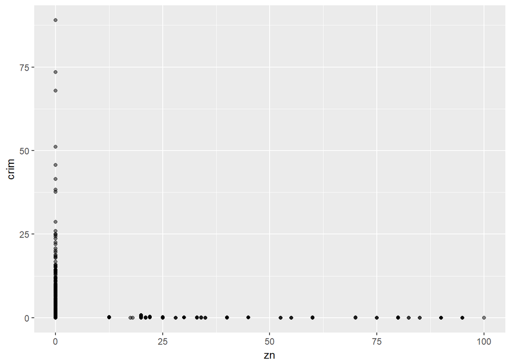

```r
# per capita crime rate by town vs proportion of residential land zoned for lots over 25,000 sq.ft
ggplot(BostonHousing, aes(zn, crim)) + geom_point(alpha = 0.5)
```

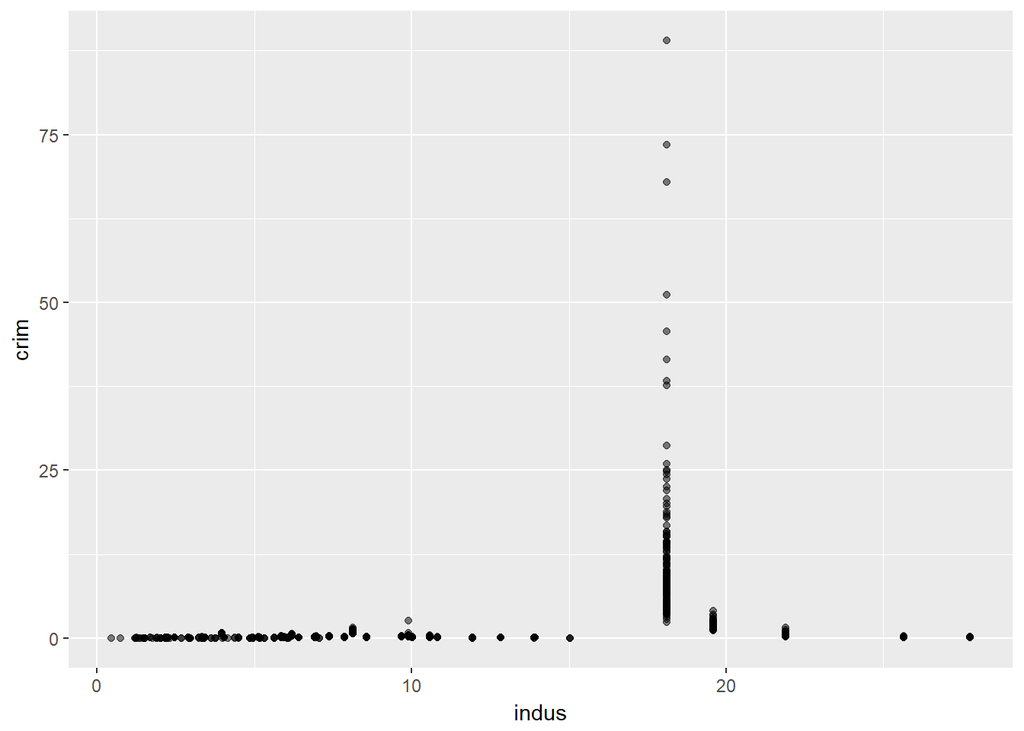

```r
# per capita crime rate by town vs proportion of non-retail business acres per town
ggplot(BostonHousing, aes(indus, crim)) + geom_point(alpha = 0.5)
```

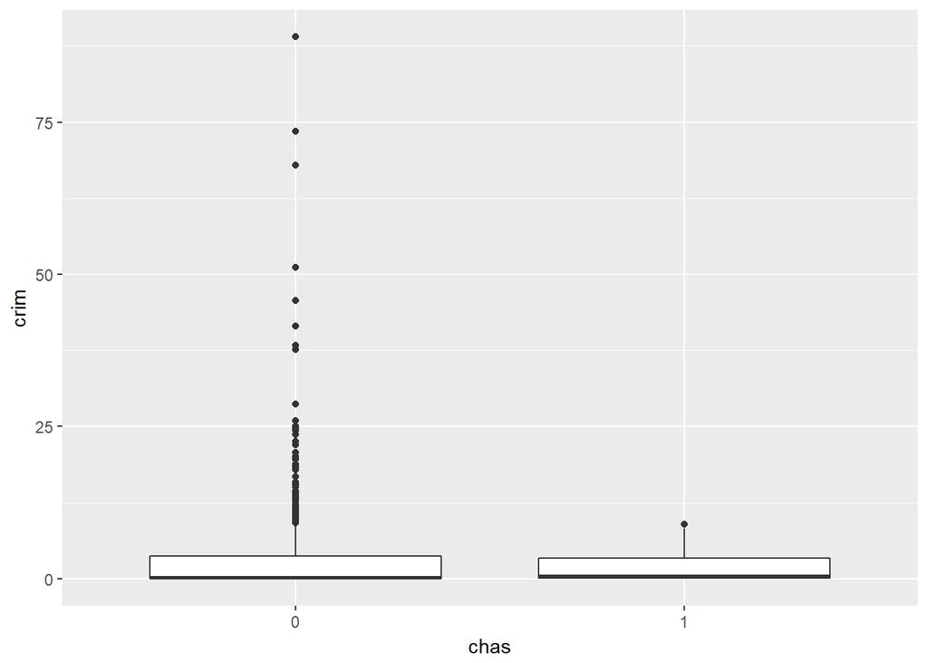

```r
# per capita crime rate by town vs Charles River dummy variable (= 1 if tract bounds river; 0 otherwise)
ggplot(BostonHousing, aes(chas, crim)) + geom_boxplot()
```

```r
#chas seems to be a categorical variable and hence boxplot is used.
```

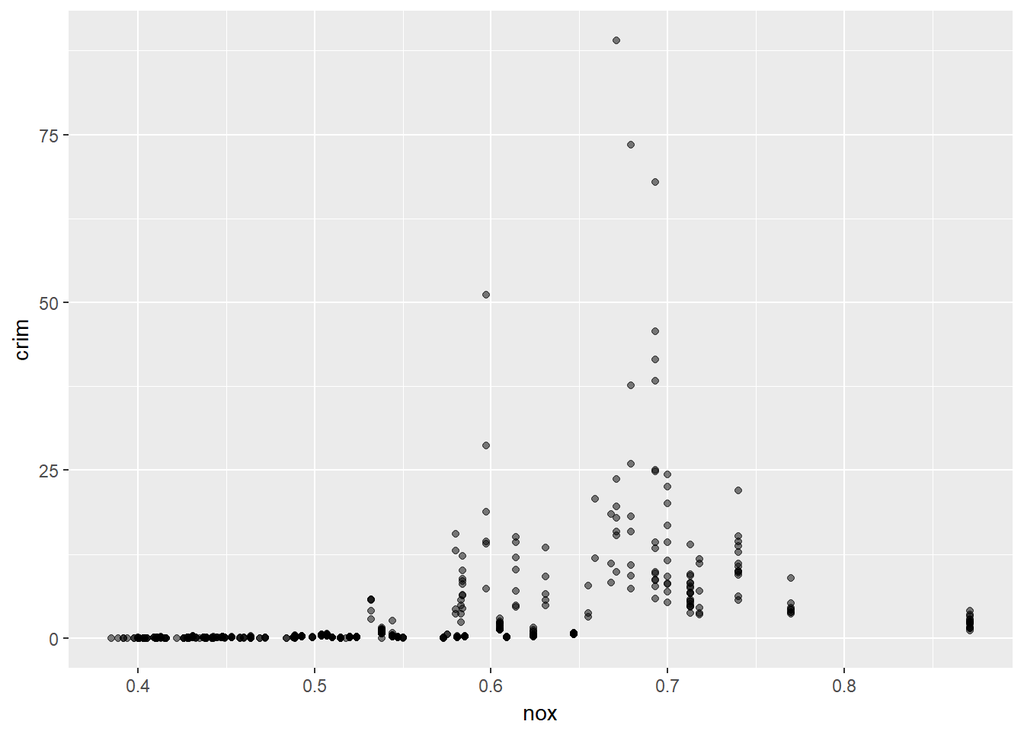

```r
# per capita crime rate by town vs nitric oxides concentration (parts per 10 million)
ggplot(BostonHousing, aes(nox, crim)) + geom_point(alpha = 0.5)
```

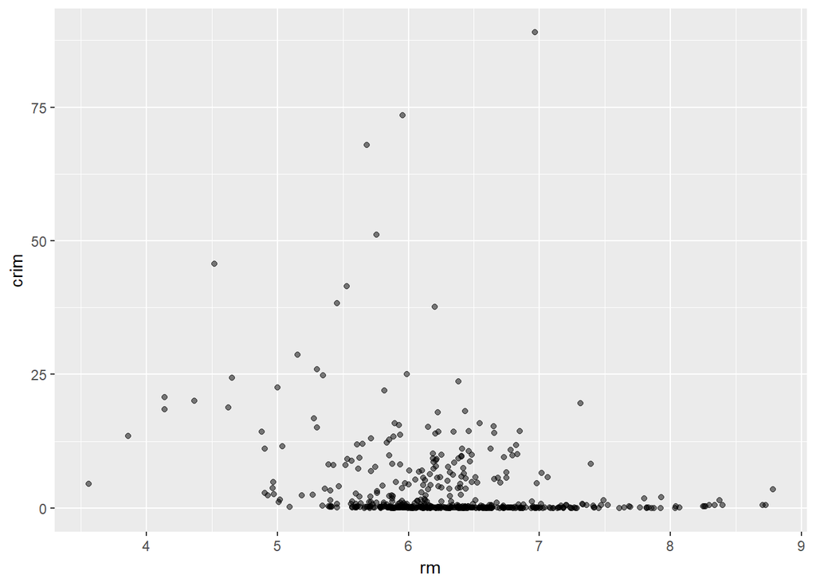

```r
# per capita crime rate by town vs average number of rooms per dwelling
ggplot(BostonHousing, aes(rm, crim)) + geom_point(alpha = 0.5)
```

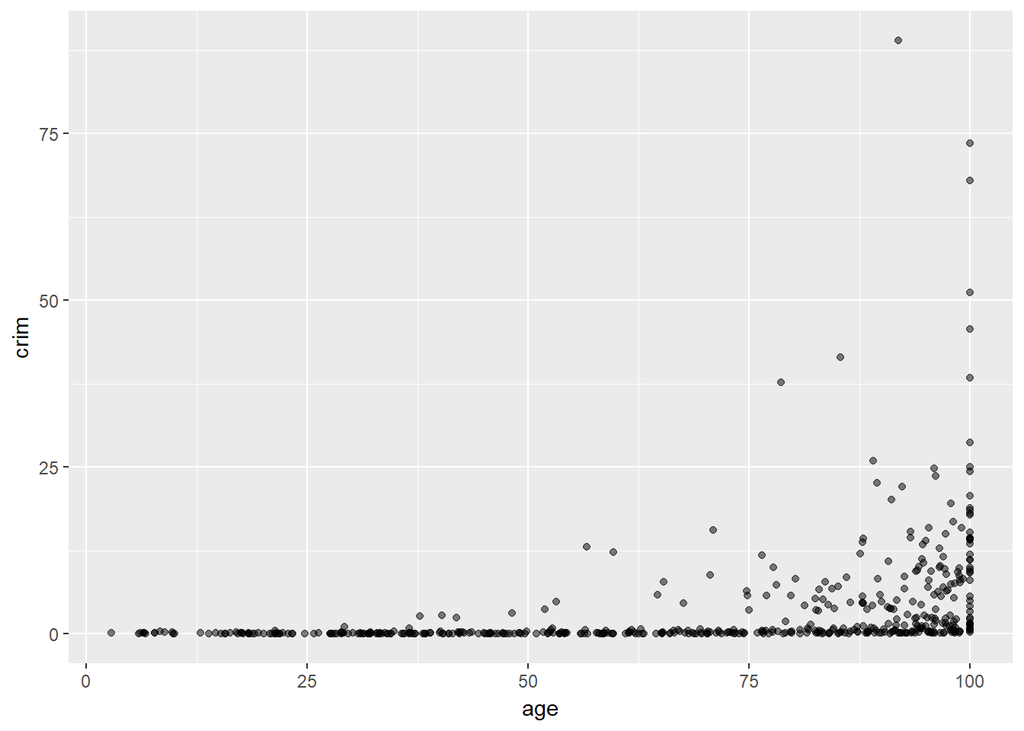

```r
# per capita crime rate by town vs proportion of owner-occupied units built prior to 1940
ggplot(BostonHousing, aes(age, crim)) + geom_point(alpha = 0.5)
```

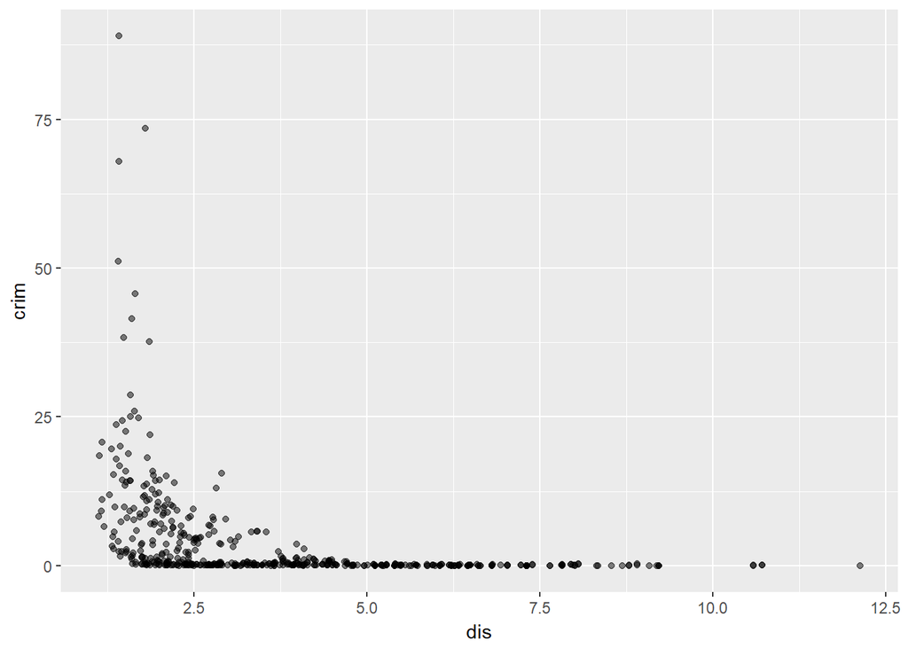

```r
# per capita crime rate by town vs weighted distances to five Boston employment centres
ggplot(BostonHousing, aes(dis, crim)) + geom_point(alpha = 0.5)
```

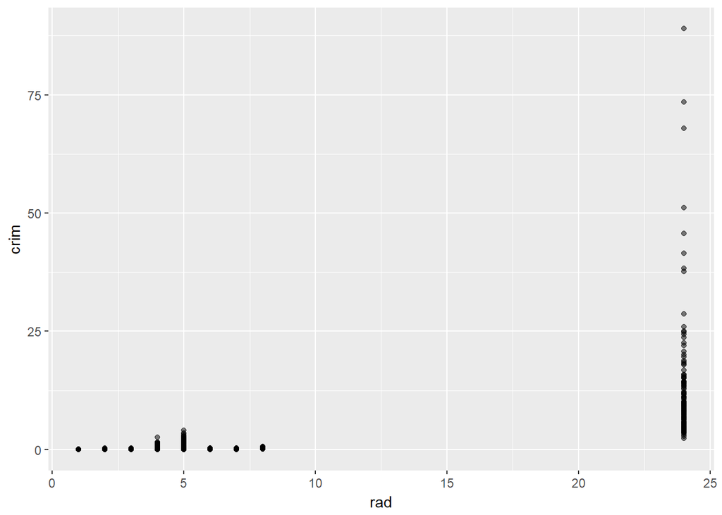

```r
# per capita crime rate by town vs index of accessibility to radial highways
ggplot(BostonHousing, aes(rad, crim)) + geom_point(alpha = 0.5)
```

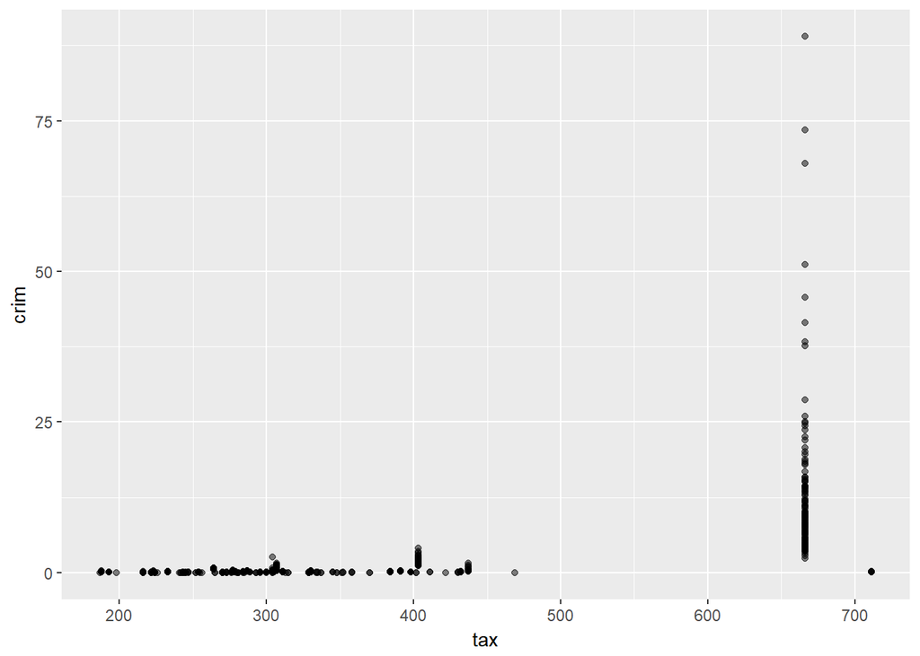

```r
# per capita crime rate by town vs full-value property-tax rate per USD 10,000
ggplot(BostonHousing, aes(tax, crim)) + geom_point(alpha = 0.5)
```

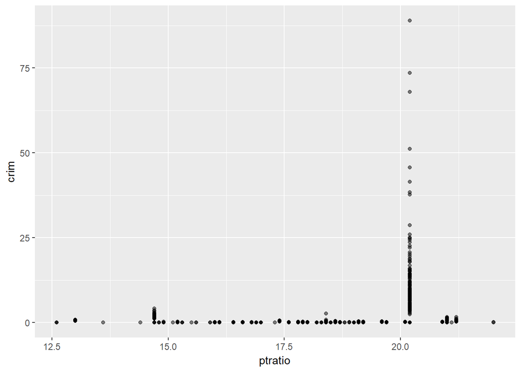

```r
# per capita crime rate by town vs pupil-teacher ratio by town
ggplot(BostonHousing, aes(ptratio, crim)) + geom_point(alpha = 0.5)
```

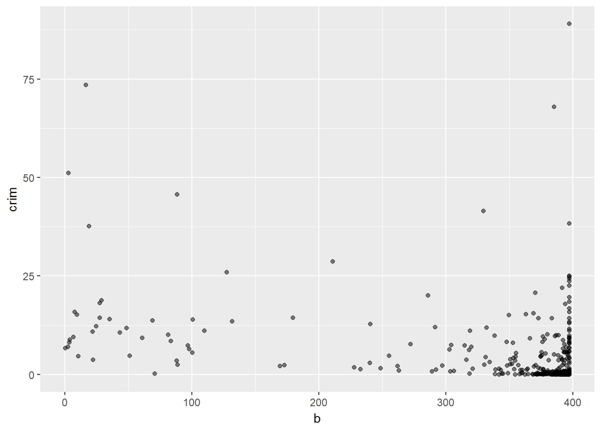

```r
# per capita crime rate by town vs 1000(B - 0.63)^2 where B is the proportion of blacks by town
ggplot(BostonHousing, aes(b, crim)) + geom_point(alpha = 0.5)
```

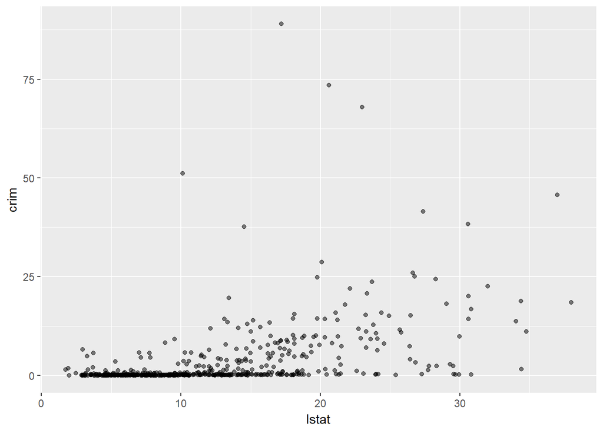

```r
# per capita crime rate by town vs percentage of lower status of the population
ggplot(BostonHousing, aes(lstat, crim)) + geom_point(alpha = 0.5)
```

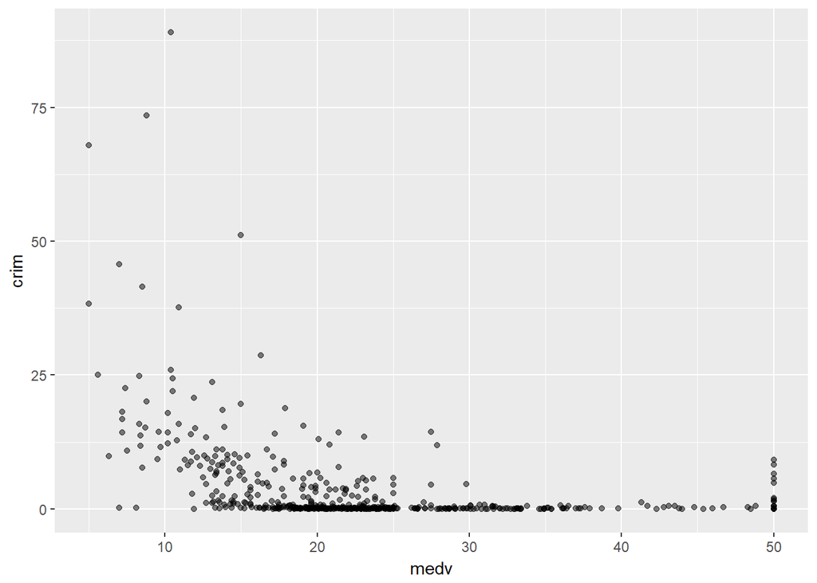

```r
# per capita crime rate by town vs median value of owner-occupied homes in USD 1000's
ggplot(BostonHousing, aes(medv, crim)) + geom_point(alpha = 0.5)
```

We see no obvious pattern and also the points are closely knitted which is making prediction a complex one. So we are trying to scatter the points in the plot.

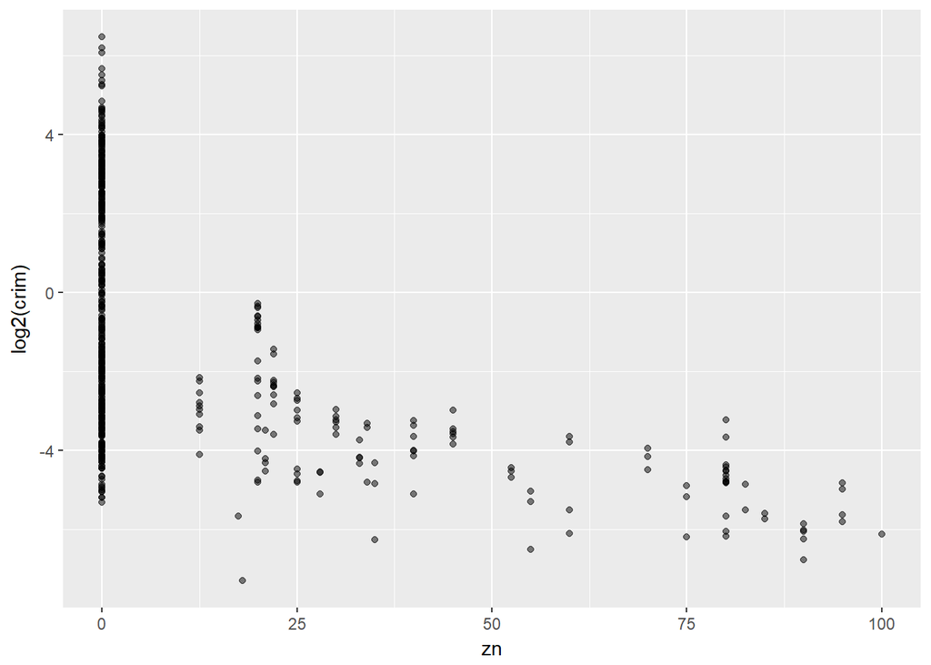

```r
# trying to scatter the points on the plot using log2/log for better visibility.
# per capita crime rate by town vs proportion of residential land zoned for lots over 25,000 sq.ft
ggplot(BostonHousing, aes(zn, log2(crim))) + geom_point(alpha = 0.5)
```

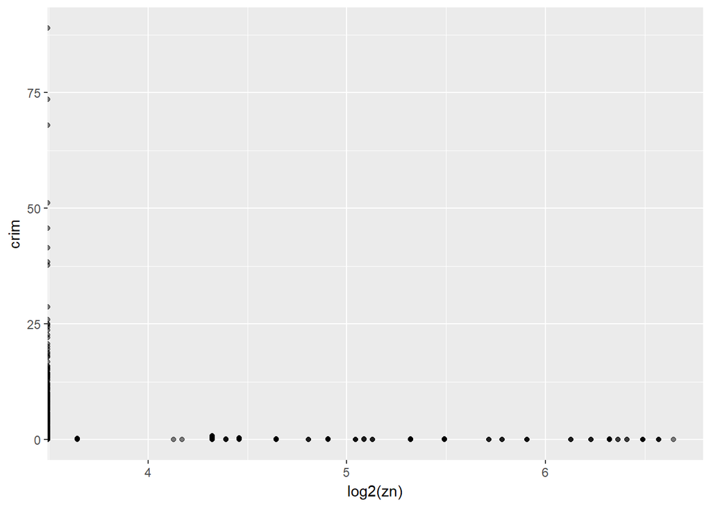

```r
#trying log2/log with predictor variable to check if any significant differences or patterns can be observed.
# per capita crime rate by town vs proportion of residential land zoned for lots over 25,000 sq.ft
ggplot(BostonHousing, aes(log2(zn), crim)) + geom_point(alpha = 0.5)
```